# Rapport - Données manquantes

#### Nom et Prénom des étudiants du groupe :

[output not shown]

### 1. Introduction

Présentation des données et objectifs de l’étude

https://www.kaggle.com/uciml/pima-indians-diabetes-database

- Context This dataset is originally from the National Institute of Diabetes and Digestive and Kidney Diseases. The objective of the dataset is to diagnostically predict whether or not a patient has diabetes, based on certain diagnostic measurements included in the dataset. Several constraints were placed on the selection of these instances from a larger database. In particular, all patients here are females at least 21 years old of Pima Indian heritage.
- Content The datasets consists of several medical predictor variables and one target variable, Outcome. Predictor variables includes the number of pregnancies the patient has had, their BMI, insulin level, age, and so on.
- Objectif Prédire si l’individu a le diabête ou pas. Construire un modèle dans ce but. Auparavant compléter les données manquante par imputation multiple.

Columns

npreg : PregnanciesNumber of times pregnant glu : GlucosePlasma glucose concentration a 2 hours in an oral glucose tolerance test bp : BloodPressureDiastolic blood pressure (mm Hg) skin : SkinThicknessTriceps skin fold thickness (mm) Insuline : Insulin2-Hour serum insulin (mu U/ml) bmi : BMIBody mass index (weight in kg/(height in m)^2) ped : DiabetesPedigreeFunctionDiabetes pedigree function age : AgeAge (years) type : OutcomeClass variable (0 or 1) 268 of 768 are 1, the others are 0

- Librayries

[output not shown]

[output not shown]

#### Chargement des donnés - Résumé

```r
data<-read.table("Pima_DataWithNA.txt",sep=";" ,header=T, na.strings = "NA")
#View(data)
summary(data)
```

```
##        Id            npreg             glu              bp
##  Min.   :  1.0   Min.   : 0.000   Min.   : 44.0   Min.   : 24.00
##  1st Qu.:192.8   1st Qu.: 1.000   1st Qu.: 99.0   1st Qu.: 64.00
##  Median :384.5   Median : 3.000   Median :117.0   Median : 72.00
##  Mean   :384.5   Mean   : 3.845   Mean   :121.7   Mean   : 72.41
##  3rd Qu.:576.2   3rd Qu.: 6.000   3rd Qu.:141.0   3rd Qu.: 80.00
##  Max.   :768.0   Max.   :17.000   Max.   :199.0   Max.   :122.00
##                                   NA's   :5       NA's   :35
##       skin          Insuline           bmi             ped
##  Min.   : 7.00   Min.   : 14.00   Min.   :18.20   Min.   :0.0780
##  1st Qu.:22.00   1st Qu.: 76.25   1st Qu.:27.50   1st Qu.:0.2437
##  Median :29.00   Median :125.00   Median :32.30   Median :0.3725
##  Mean   :29.15   Mean   :155.55   Mean   :32.46   Mean   :0.4719
##  3rd Qu.:36.00   3rd Qu.:190.00   3rd Qu.:36.60   3rd Qu.:0.6262
##  Max.   :99.00   Max.   :846.00   Max.   :67.10   Max.   :2.4200
##  NA's   :227     NA's   :374      NA's   :11
##       age             type
##  Min.   :21.00   Min.   :0.000
##  1st Qu.:24.00   1st Qu.:0.000
##  Median :29.00   Median :0.000
##  Mean   :33.24   Mean   :0.349
##  3rd Qu.:41.00   3rd Qu.:1.000
##  Max.   :81.00   Max.   :1.000
##
```

- Traitement des données

```r
#suppression de la 1er colonne (Id) et de la 6ème (Insuline)=> trop de données manquantes (peourrait être considérés dans un 2nd tps)
tab_Pima1<-data[,-1]
tab_Pima1<-tab_Pima1[,-5]
maxDim<-8 #8 si on décide de supprimer la colonne insuline 9 sinon

data_Pima1<-as.data.frame.matrix(tab_Pima1)

data_Pima1$type <- as.logical(data_Pima1$type)

dataPima<-data_Pima1[,1:maxDim]
summary(dataPima)
```

```
##      npreg             glu              bp              skin
##  Min.   : 0.000   Min.   : 44.0   Min.   : 24.00   Min.   : 7.00
##  1st Qu.: 1.000   1st Qu.: 99.0   1st Qu.: 64.00   1st Qu.:22.00
##  Median : 3.000   Median :117.0   Median : 72.00   Median :29.00
##  Mean   : 3.845   Mean   :121.7   Mean   : 72.41   Mean   :29.15
##  3rd Qu.: 6.000   3rd Qu.:141.0   3rd Qu.: 80.00   3rd Qu.:36.00
##  Max.   :17.000   Max.   :199.0   Max.   :122.00   Max.   :99.00
##                   NA's   :5       NA's   :35       NA's   :227
##       bmi             ped              age           type
##  Min.   :18.20   Min.   :0.0780   Min.   :21.00   Mode :logical
##  1st Qu.:27.50   1st Qu.:0.2437   1st Qu.:24.00   FALSE:500
##  Median :32.30   Median :0.3725   Median :29.00   TRUE :268
##  Mean   :32.46   Mean   :0.4719   Mean   :33.24
##  3rd Qu.:36.60   3rd Qu.:0.6262   3rd Qu.:41.00
##  Max.   :67.10   Max.   :2.4200   Max.   :81.00
##  NA's   :11
```

```r
#View(data_Pima1)
```

### 2. Exploration des données

```
https://www.kaggle.com/laozhang/statistical-learning-with-r
https://www.kaggle.com/naveenkhasa/pima-indian-diabetes-dataset
```

#### Classification des données manqunates: MCAR/MNAR

https://datascienceplus.com/imputing-missing-data-with-r-mice-package/

Using mice for looking at missing data pattern The mice package provides a nice function md.pattern() to get a better understanding of the pattern of missing data

```r
library(mice)
pattern<-md.pattern(dataPima)
```

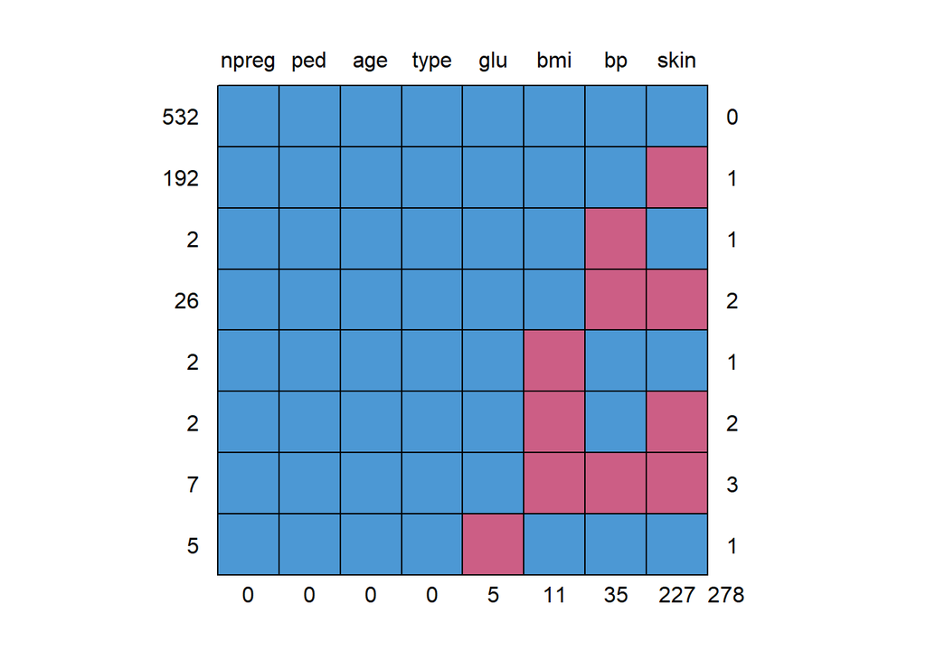

- On marque les différentes catégories de données manquantes

```r
##tager les donn"es qui ont ete complétées
# npreg

glu.na<-dataPima[is.na(dataPima$glu),0]
bp.na<-dataPima[is.na(dataPima$bp),0]
skin.na<-dataPima[is.na(dataPima$skin),0]
bmi.na<-dataPima[is.na(dataPima$bmi),0]

skin.only <- as.data.frame(dataPima[is.na(dataPima$skin) & !is.na(dataPima$bp) & !is.na(dataPima$bmi),0])
skin.bp <-  as.data.frame(dataPima[is.na(dataPima$skin) & is.na(dataPima$bp) & !is.na(dataPima$bmi),0])
skin.bmi <-  as.data.frame(dataPima[is.na(dataPima$skin) & !is.na(dataPima$bp) & is.na(dataPima$bmi),0])
skin.bp.bmi<-  as.data.frame(dataPima[is.na(dataPima$skin) & is.na(dataPima$bp) & is.na(dataPima$bmi),0])
bp.only<-  as.data.frame(dataPima[!is.na(dataPima$skin) & is.na(dataPima$bp) & !is.na(dataPima$bmi),0])
bmi.only<-  as.data.frame(dataPima[!is.na(dataPima$skin) & !is.na(dataPima$bp) & is.na(dataPima$bmi),0])
glu.only<-  as.data.frame(dataPima[is.na(dataPima$glu),0])

dim(skin.only)[1]
```

```
## [1] 192
```

```r
dim(skin.bp)[1]
```

```
## [1] 26
```

```r
dim(skin.bmi)[1]
```

```
## [1] 2
```

```r
dim(skin.bp.bmi)[1]
```

```
## [1] 7
```

```r
dim(bp.only)[1]
```

```
## [1] 2
```

```r
dim(bmi.only)[1]
```

```
## [1] 2
```

```r
dim(glu.only)[1]
```

```
## [1] 5
```

```r
nb.rows<-dim(dataPima)[1]

missingCateg <- replicate(nb.rows, 0)
dataPima.MissingCateg <- cbind(dataPima,missingCateg)
colCateg<-9
dataPima.MissingCateg$missingCateg <- as.integer(dataPima.MissingCateg$missingCateg)

#dataFramePima<-as.data.frame(dataPCA)


set_categ<-function(data,index,categ,colCateg)
{
  size<-dim(index)
  for(i in 1:size)
  {
    data[index[i,0],9]<-1;
  }
  #return (data);
}
#set_categ(dataPima.MissingCateg,skin.only,1,9)

#p<-skin.only[1,0]
#  dataPima.MissingCateg[p,9]

#dataPima.MissingCateg<-set_categ(dataPima.MissingCateg,skin.only[,0],1,9)
#dataPima.MissingCateg<-set_categ(dataPima.MissingCateg,skin.bp,2,9)
#dataPima.MissingCateg<-set_categ(dataPima.MissingCateg,skin.bmi,3,9)
#dataPima.MissingCateg<-set_categ(dataPima.MissingCateg,skin.bp.bmi,4,9)
#dataPima.MissingCateg<-set_categ(dataPima.MissingCateg,bp.only,5,9)
#dataPima.MissingCateg<-set_categ(dataPima.MissingCateg,bmi.only,6,9)
#dataPima.MissingCateg<-set_categ(dataPima.MissingCateg,glu.only,7,9)
```

A perhaps more helpful visual representation can be obtained using the VIM package as follows

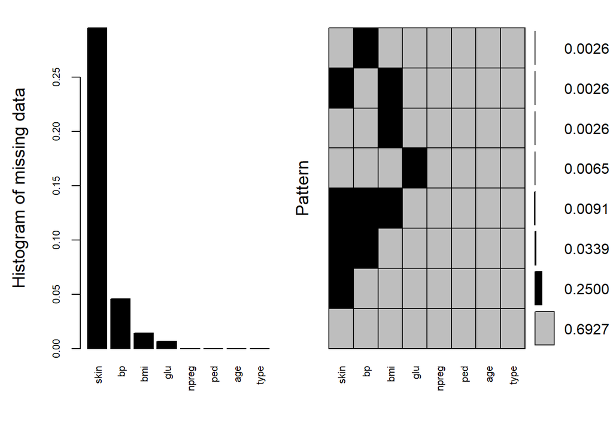

```
##
##  Variables sorted by number of missings:
##  Variable       Count
##      skin 0.295572917
##        bp 0.045572917
##       bmi 0.014322917
##       glu 0.006510417
##     npreg 0.000000000
##       ped 0.000000000
##       age 0.000000000
##      type 0.000000000
```

```r
library(VIM)
aggr_plot <- aggr(dataPima, col=c('grey','black'), numbers=TRUE, sortVars=TRUE, labels=names(dataPima), cex.axis=.7, gap=3, ylab=c("Histogram of missing data","Pattern"))
```

Another (hopefully) helpful visual approach is a special box plot

[figure not shown]

```r
par(mfrow=c(1,2))
marginplot(data[c(4,5)])
marginplot(data[c(7,5)])
```

```r
#marginplot(data[c(5,8)])
```

### 3. Imputation

Dans un premier temps on traite les valeurs manquantes. A partir des jeux de données complétés par imputation (test de différents méthodes) simple ou multiple on construit un modèle de type logit pour la variable réponse. Dans notre cas Le patient est diabétique ou pas.

#### 3.2 Imputation multiple avec MIPCA

- Détermination de la dimension de l’espace de projection

```r
nb.kfold$ncp
```

```
## [1] 5
```

```r
nb_Pima1$ncp
```

```
## [1] 1
```

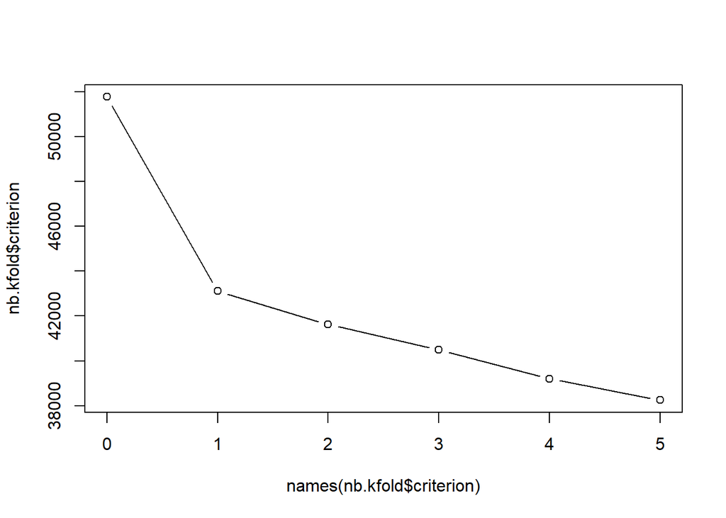

```r
plot(names(nb.kfold$criterion),nb.kfold$criterion,type="b")
```

nb_Pima1 = 1 nb.kfold$ncp = 5 avec insuline=>4

big différence! Les résultats sont meilleur avec 5

Peut être utilser 4

```r
#setting des variables
ncp.res<-nb.kfold$ncp
#ncp.res<-nb_Pima1$ncp
dataImp<-data_Pima1[,1:maxDim]
dataPima<-data_Pima1[,1:maxDim]
```

#### 3.2.1 Multiple Imputation with Bayesian method

En changeant le nb de dimensions : de 1 à 5 le résultat est meilleur Pb pour la variabble ped mais peu d’individus concernés => ped>1.5

#### 3.2.2 Multiple Imputation with Bayesian method et EM

=> pas vraiment d’améliorations

#### 3.2.3 Multiple Imputation with Boost method

Le résultat semble meilleur

#### 3.2.4 Multiple Imputation with MIPCA Boost method

Le obtenu par boostrap et method= “EM” semble le meilleur résultat

```r
## Diagnostics
res.overEMBoot_Pima1<-Overimpute(res.EMBootMIPCA_Pima1)
```

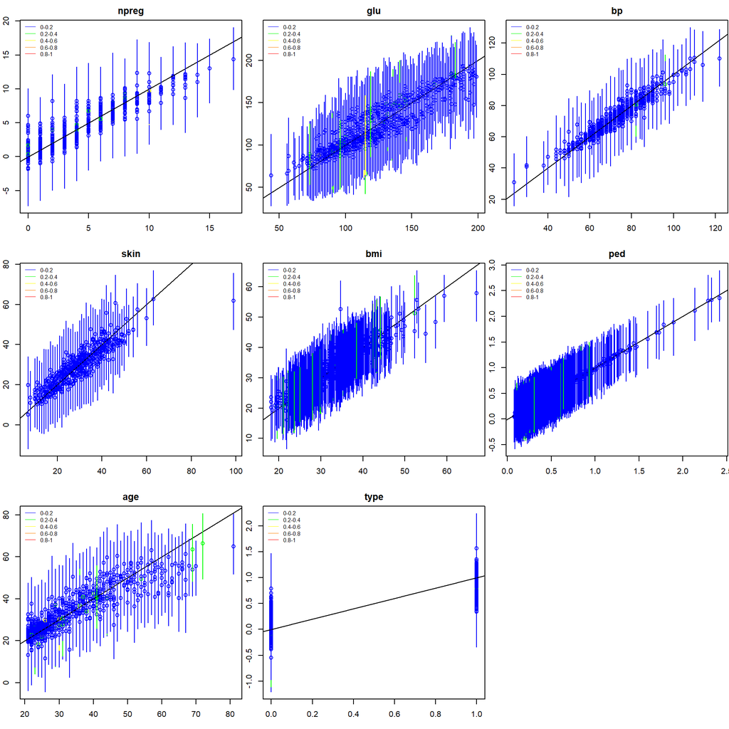

```r
## Diagnostics
plot(res.EMBootMIPCA_Pima1)
```

#### 3.3 Imputation multiple autres méthodes

Finalement le MIFAMD ne semble pas approprié Peut-être tester d’autres méthodes du package MICE par exemple…

https://datascienceplus.com/imputing-missing-data-with-r-mice-package/

```
## Class: mids
## Number of multiple imputations:  5
## Imputation methods:
## npreg   glu    bp  skin   bmi   ped   age  type
##    "" "pmm" "pmm" "pmm" "pmm"    ""    ""    ""
## PredictorMatrix:
##       npreg glu bp skin bmi ped age type
## npreg     0   1  1    1   1   1   1    1
## glu       1   0  1    1   1   1   1    1
## bp        1   1  0    1   1   1   1    1
## skin      1   1  1    0   1   1   1    1
## bmi       1   1  1    1   0   1   1    1
## ped       1   1  1    1   1   0   1    1
```

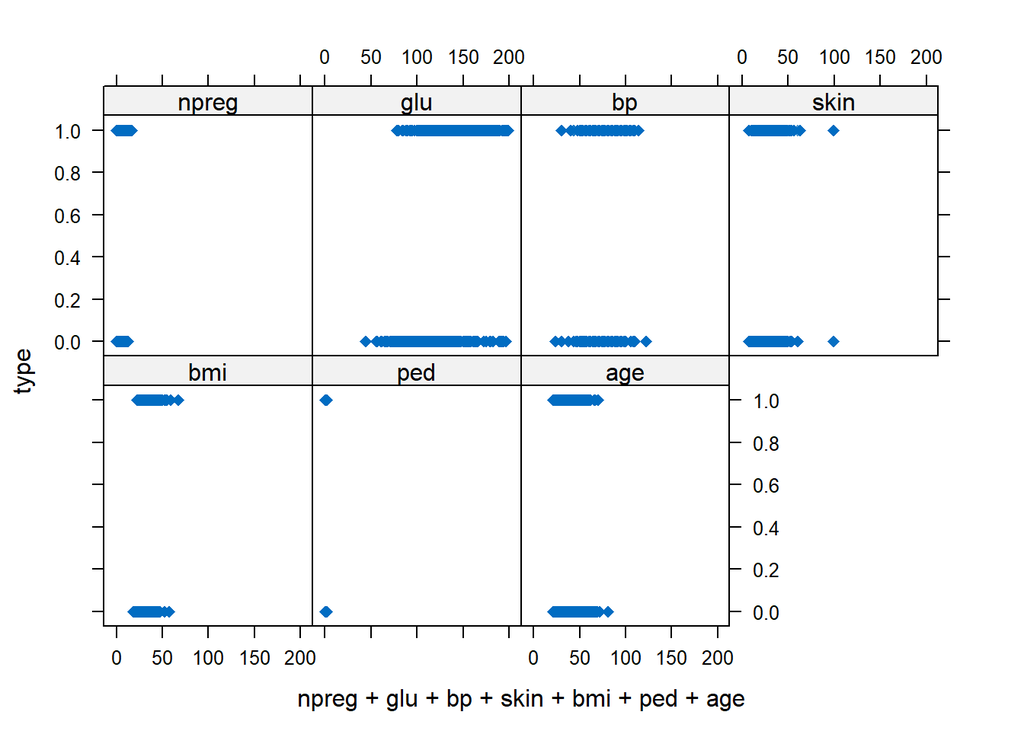

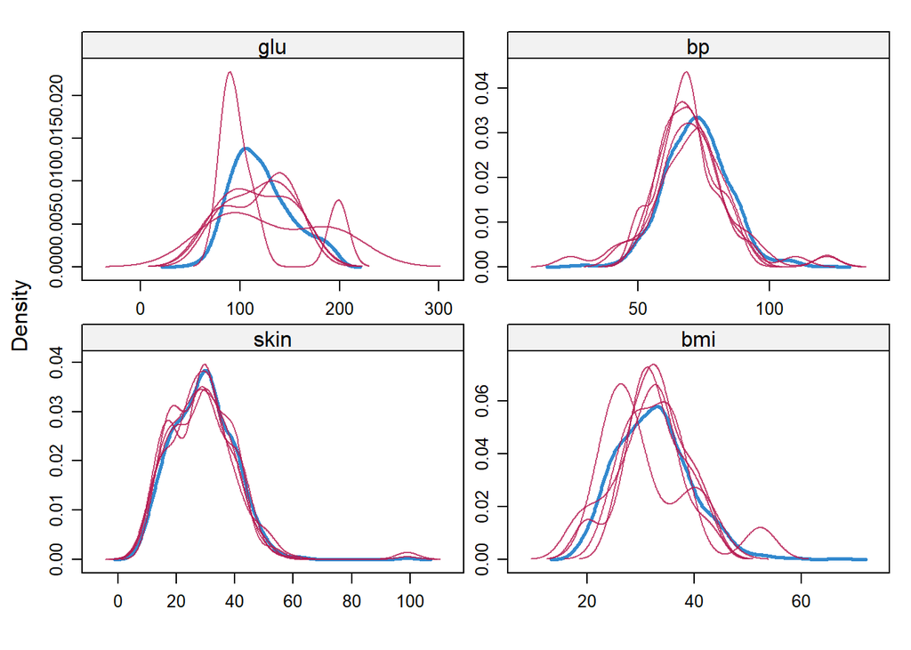

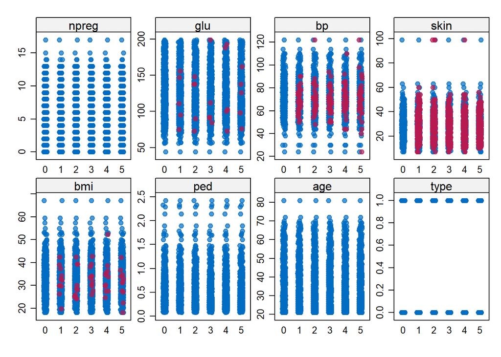

#### 3.4 Remarques :

- Comparaison des données complétées (par MIPCA et mice) aux données de la librairie MASS (sous échantillon) - Etude des Correlation

```
##      npreg             glu              bp              skin
##  Min.   : 0.000   Min.   : 44.0   Min.   : 24.00   Min.   : 2.071
##  1st Qu.: 1.000   1st Qu.: 99.0   1st Qu.: 64.00   1st Qu.:20.000
##  Median : 3.000   Median :117.0   Median : 72.00   Median :29.000
##  Mean   : 3.846   Mean   :121.7   Mean   : 71.95   Mean   :28.660
##  3rd Qu.: 6.000   3rd Qu.:141.0   3rd Qu.: 80.00   3rd Qu.:35.695
##  Max.   :17.000   Max.   :199.0   Max.   :122.00   Max.   :99.000
##       bmi             ped              age           type
##  Min.   :18.20   Min.   :0.0780   Min.   :21.00   Mode :logical
##  1st Qu.:27.52   1st Qu.:0.2432   1st Qu.:24.00   FALSE:498
##  Median :32.35   Median :0.3705   Median :29.00   TRUE :268
##  Mean   :32.50   Mean   :0.4712   Mean   :33.14
##  3rd Qu.:36.60   3rd Qu.:0.6228   3rd Qu.:40.75
##  Max.   :67.10   Max.   :2.4200   Max.   :81.00
```

```
##      npreg             glu              bp              skin
##  Min.   : 0.000   Min.   : 44.0   Min.   : 24.00   Min.   : 7.00
##  1st Qu.: 1.000   1st Qu.: 99.0   1st Qu.: 64.00   1st Qu.:21.75
##  Median : 3.000   Median :117.0   Median : 72.00   Median :29.00
##  Mean   : 3.845   Mean   :121.7   Mean   : 72.24   Mean   :28.94
##  3rd Qu.: 6.000   3rd Qu.:141.0   3rd Qu.: 80.00   3rd Qu.:36.00
##  Max.   :17.000   Max.   :199.0   Max.   :122.00   Max.   :99.00
##       bmi             ped              age           type
##  Min.   :18.20   Min.   :0.0780   Min.   :21.00   Mode :logical
##  1st Qu.:27.50   1st Qu.:0.2437   1st Qu.:24.00   FALSE:500
##  Median :32.30   Median :0.3725   Median :29.00   TRUE :268
##  Mean   :32.45   Mean   :0.4719   Mean   :33.24
##  3rd Qu.:36.60   3rd Qu.:0.6262   3rd Qu.:41.00
##  Max.   :67.10   Max.   :2.4200   Max.   :81.00
```

```
##      npreg            glu              bp              skin
##  Min.   : 0.00   Min.   : 56.0   Min.   : 38.00   Min.   : 7.00
##  1st Qu.: 1.00   1st Qu.:100.0   1st Qu.: 64.00   1st Qu.:20.75
##  Median : 2.00   Median :120.5   Median : 70.00   Median :29.00
##  Mean   : 3.57   Mean   :124.0   Mean   : 71.26   Mean   :29.21
##  3rd Qu.: 6.00   3rd Qu.:144.0   3rd Qu.: 78.00   3rd Qu.:36.00
##  Max.   :14.00   Max.   :199.0   Max.   :110.00   Max.   :99.00
##       bmi             ped              age         type
##  Min.   :18.20   Min.   :0.0850   Min.   :21.00   No :132
##  1st Qu.:27.57   1st Qu.:0.2535   1st Qu.:23.00   Yes: 68
##  Median :32.80   Median :0.3725   Median :28.00
##  Mean   :32.31   Mean   :0.4608   Mean   :32.11
##  3rd Qu.:36.50   3rd Qu.:0.6160   3rd Qu.:39.25
##  Max.   :47.90   Max.   :2.2880   Max.   :63.00
```

Les correlations très voisines, tendance à baisser pour les données imputés (sauf pour corr bmi / skin ) La structure globale des corrélations est très voisine.

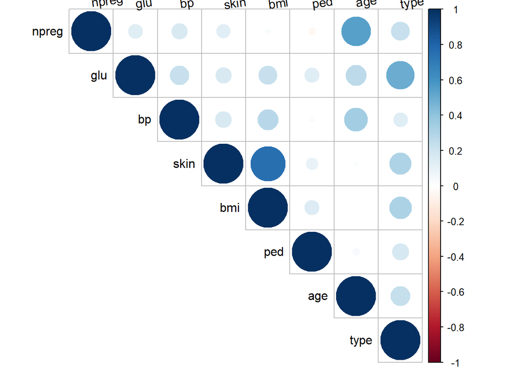

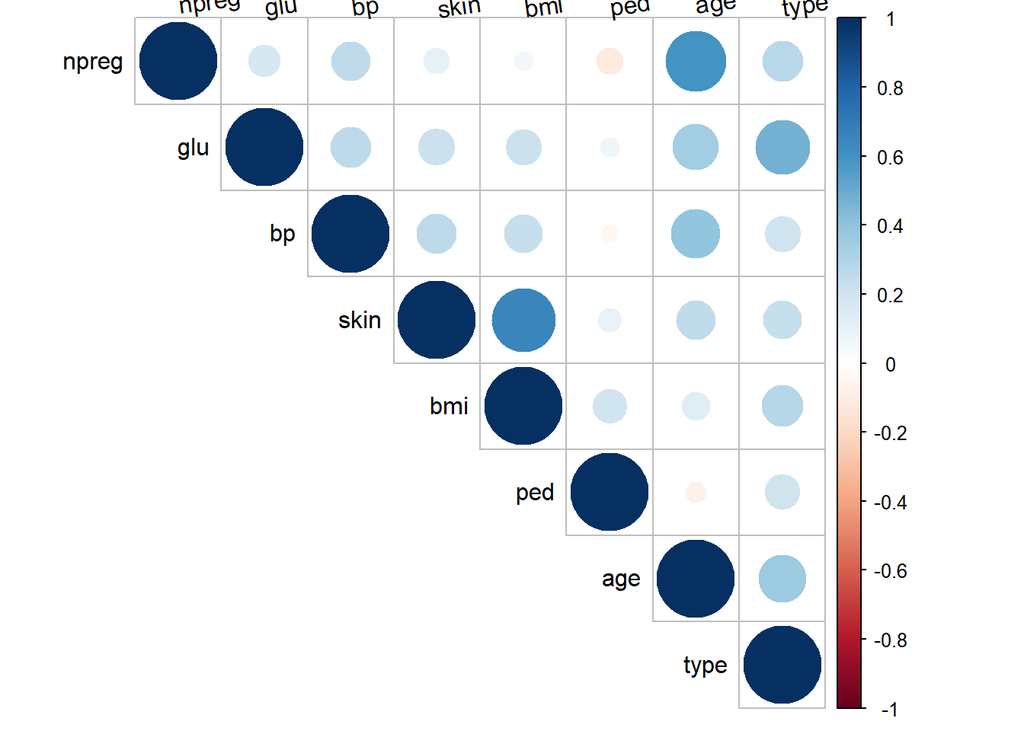

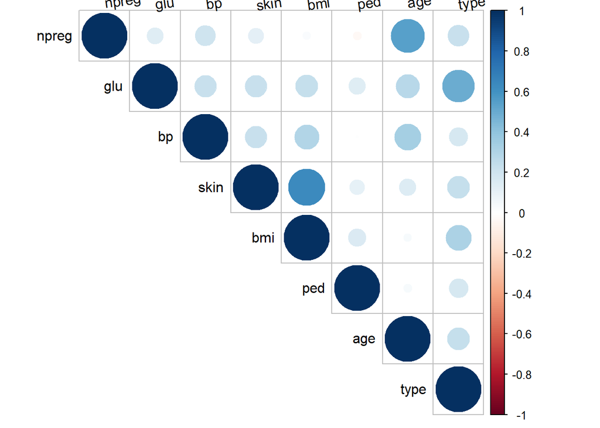

- Inspecting the distribution of original and imputed data avec MICE
- Inspecting the distribution of original and imputed data avec MIPCA

```r
dataPima_NA<-data_Pima1[,1:maxDim]
#mi<-res.BayesMIPCA_Pima1
mi.res<-res.EMBootMIPCA_Pima1

tempData_MIPCA<-prelim(res.mi=mi.res,X=dataPima_NA)#creating a mids object
#help("prelim")
#data_MIPCA<-res.EMBootMIPCA_Pima1$res.imputePCA
#DataMat=data.matrix(data_MIPCA)
#frameData_MIPCA<-as.data.frame(data_MIPCA)
#frameData_MIPCA$type <- as.logical(frameData_MIPCA$type)

#tempData_MIPCA<-prelim(res.mi=mi.res,X=frameData_MIPCA)#creating a mids object
```

```r
##ne semble pas fonctionner? pb de la conversion vers mice?
xyplot(tempData_MIPCA, type ~ npreg + glu + bp + skin + bmi +  ped + age, pch=18,cex=1)
densityplot(tempData_MIPCA)
stripplot(tempData_MIPCA, pch = 20, cex = 1.2)
```

### 4. Modélisation de la variable réponse

A partir des données complétés. Le modèle de la variable réponse: “Individus diabétique” (variable “type” : Yes/No) est un modèle logit. Regression linéaire généralisé sur les variables explicatives: npreg + glu + bp + skin + bmi + ped + age

Regression on the multiply imputed data set and pooling with mice

```r
dataPima<-data_Pima1[,1:maxDim] #dataImp
#mi<-res.BayesMIPCA_Pima1
mi.res<-res.EMBootMIPCA_Pima1

imp_Pima1<-prelim(res.mi=mi.res,X=dataPima)#creating a mids object

#MICE: with.mids Evaluate an expression in multiple imputed datasets
fit_Pima1_m1 <- with(data=imp_Pima1,exp=glm(type ~ npreg + glu + bp + skin + bmi +  ped + age,family=binomial))
fit_Pima1_m2 <- with(data=imp_Pima1,exp=glm(type ~ npreg + glu + bp + bmi +  ped + age ,family=binomial))
fit_Pima1_m3 <- with(data=imp_Pima1,exp=glm(type ~ npreg + glu + skin + bmi +  ped + age,family=binomial))
fit_Pima1_m4 <- with(data=imp_Pima1,exp=glm(type ~ npreg + glu + bmi +  ped + age,family=binomial))
fit_Pima1_m5 <- with(data=imp_Pima1,exp=glm(type ~ npreg + glu + bmi +  ped ,family=binomial))
fit_Pima1_m6 <- with(data=imp_Pima1,exp=glm(type ~ npreg + glu + bmi +  ped ,family=binomial))
fit_Pima1_m7 <- with(data=imp_Pima1,exp=glm(type ~ npreg + glu + ped ,family=binomial))
fit_Pima1_m8 <- with(data=imp_Pima1,exp=glm(type ~ glu + ped ,family=binomial))
#anova.imp <- with(data=imp_Pima1,exp=anova(lm(type ~ npreg + glu + bp + skin + bmi +  ped + age)))
```

#### Choix du modèle - anova

```r
anova(fit_Pima1_m1,fit_Pima1_m2)
```

```
##    test statistic df1      df2 df.com    p.value       riv
##  1 ~~ 2  2.971314   1 333.2594    760 0.08568039 0.6578445
```

```r
anova(fit_Pima1_m1,fit_Pima1_m3)
```

```
##    test statistic df1      df2 df.com    p.value       riv
##  1 ~~ 2  4.143853   1 566.7928    760 0.04225052 0.2544145
```

```r
anova(fit_Pima1_m1,fit_Pima1_m4)
```

```
##    test statistic df1      df2 df.com    p.value       riv
##  1 ~~ 2  3.418576   2 545.2394    760 0.03346286 0.4582122
```

```r
anova(fit_Pima1_m1,fit_Pima1_m5)
```

```
##    test statistic df1      df2 df.com    p.value       riv
##  1 ~~ 2  2.919566   3 660.1762    760 0.03344077 0.3118297
```

```r
anova(fit_Pima1_m1,fit_Pima1_m6)
```

```
##    test statistic df1      df2 df.com    p.value       riv
##  1 ~~ 2  2.919566   3 660.1762    760 0.03344077 0.3118297
```

```r
anova(fit_Pima1_m1,fit_Pima1_m7)
```

```
##    test statistic df1      df2 df.com      p.value       riv
##  1 ~~ 2  8.056338   4 659.5751    760 2.408609e-06 0.3811568
```

```r
anova(fit_Pima1_m1,fit_Pima1_m8)
```

```
##    test statistic df1      df2 df.com      p.value       riv
##  1 ~~ 2   9.71384   5 697.4075    760 5.542039e-09 0.3074814
```

```r
anova(fit_Pima1_m6,fit_Pima1_m8)
```

```
##    test statistic df1      df2 df.com     p.value      riv
##  1 ~~ 2  19.68645   2 588.5577    763 5.29801e-09 0.372718
```

```r
anova(fit_Pima1_m7,fit_Pima1_m8)
```

```
##    test statistic df1      df2 df.com     p.value          riv
##  1 ~~ 2  24.49408   1 762.0034    764 9.17996e-07 0.0005700039
```

Choix du plus grand modèle?

#### Choix du modèle - Utilisation de regsubsets à partir du modèle réduit m_PCA

Là encore le résultat n’est pas satisfaisant.

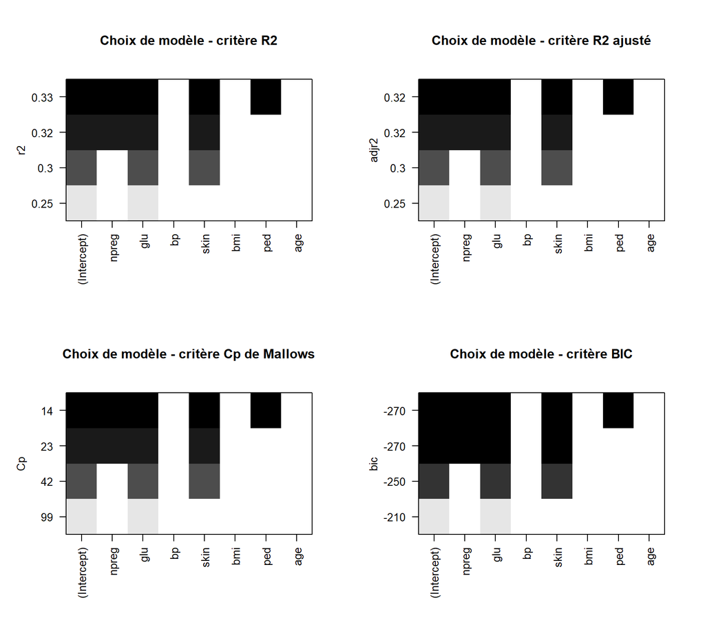

La méthode step du package leaps nous fait choisir un modèle à 4 variables explicatives: npreg + glu + skin + ped

#### Choix du modèle - méthode step du package MASS à partir du modèle saturé

```r
m_sature = glm(formula = type ~ (npreg + glu + bp + skin + bmi +  ped + age),  family = binomial(link="logit"),  data = dataFramePima)
summary(m_sature)
```

```
##
## Call:
## glm(formula = type ~ (npreg + glu + bp + skin + bmi + ped + age),
##     family = binomial(link = "logit"), data = dataFramePima)
##
## Deviance Residuals:
##     Min       1Q   Median       3Q      Max
## -2.9289  -0.6814  -0.3678   0.7031   2.3986
##
## Coefficients:
##              Estimate Std. Error z value Pr(>|z|)
## (Intercept) -8.659000   0.779243 -11.112  < 2e-16 ***
## npreg        0.097817   0.033302   2.937  0.00331 **
## glu          0.038131   0.003677  10.371  < 2e-16 ***
## bp          -0.018714   0.008129  -2.302  0.02132 *
## skin         0.042325   0.013837   3.059  0.00222 **
## bmi          0.053510   0.021546   2.484  0.01301 *
## ped          0.875138   0.301234   2.905  0.00367 **
## age          0.022212   0.010093   2.201  0.02776 *
## ---
## Signif. codes:  0 '***' 0.001 '**' 0.01 '*' 0.05 '.' 0.1 ' ' 1
##
## (Dispersion parameter for binomial family taken to be 1)
##
##     Null deviance: 993.48  on 767  degrees of freedom
## Residual deviance: 694.01  on 760  degrees of freedom
## AIC: 710.01
##
## Number of Fisher Scoring iterations: 5
```

#### Choix du modèle - Méthode progressive - step backward-forward à partir de m_sature

- Critère AIC

```r
library(MASS)
modele_step_BwdFwd_AIC <- step(m_sature, data=dataFramePima, direction="both")
#help("step")
```

- Critère BIC

```r
K<-log(dim(dataFramePima)[1])
m_StepBwdFwd_BIC <- step(m_sature, data=dataFramePima, direction="both",k=K)
#help("step")
```

##### Choix du modèle - Modèle obtenu

```r
modele_step_BwdFwd_AIC<-glm(formula = type ~ (npreg + glu + bp + skin + bmi + ped + age), family = binomial, data = dataFramePima)
summary(modele_step_BwdFwd_AIC)
```

```
##
## Call:
## glm(formula = type ~ (npreg + glu + bp + skin + bmi + ped + age),
##     family = binomial, data = dataFramePima)
##
## Deviance Residuals:
##     Min       1Q   Median       3Q      Max
## -2.9289  -0.6814  -0.3678   0.7031   2.3986
##
## Coefficients:
##              Estimate Std. Error z value Pr(>|z|)
## (Intercept) -8.659000   0.779243 -11.112  < 2e-16 ***
## npreg        0.097817   0.033302   2.937  0.00331 **
## glu          0.038131   0.003677  10.371  < 2e-16 ***
## bp          -0.018714   0.008129  -2.302  0.02132 *
## skin         0.042325   0.013837   3.059  0.00222 **
## bmi          0.053510   0.021546   2.484  0.01301 *
## ped          0.875138   0.301234   2.905  0.00367 **
## age          0.022212   0.010093   2.201  0.02776 *
## ---
## Signif. codes:  0 '***' 0.001 '**' 0.01 '*' 0.05 '.' 0.1 ' ' 1
##
## (Dispersion parameter for binomial family taken to be 1)
##
##     Null deviance: 993.48  on 767  degrees of freedom
## Residual deviance: 694.01  on 760  degrees of freedom
## AIC: 710.01
##
## Number of Fisher Scoring iterations: 5
```

```r
AIC(modele_step_BwdFwd_AIC)
```

```
## [1] 710.0123
```

```r
BIC(modele_step_BwdFwd_AIC)
```

```
## [1] 747.1627
```

```r
m_StepBwdFwd_BIC<-glm(formula = type ~ (npreg + glu + skin + ped),family = binomial, data = dataFramePima)
summary(m_StepBwdFwd_BIC)
```

```
##
## Call:
## glm(formula = type ~ (npreg + glu + skin + ped), family = binomial,
##     data = dataFramePima)
##
## Deviance Residuals:
##     Min       1Q   Median       3Q      Max
## -2.9847  -0.6842  -0.3822   0.7110   2.3863
##
## Coefficients:
##              Estimate Std. Error z value Pr(>|z|)
## (Intercept) -8.258709   0.597057 -13.832  < 2e-16 ***
## npreg        0.117666   0.027231   4.321 1.55e-05 ***
## glu          0.039233   0.003537  11.092  < 2e-16 ***
## skin         0.060712   0.009458   6.419 1.37e-10 ***
## ped          0.916137   0.293807   3.118  0.00182 **
## ---
## Signif. codes:  0 '***' 0.001 '**' 0.01 '*' 0.05 '.' 0.1 ' ' 1
##
## (Dispersion parameter for binomial family taken to be 1)
##
##     Null deviance: 993.48  on 767  degrees of freedom
## Residual deviance: 706.30  on 763  degrees of freedom
## AIC: 716.3
##
## Number of Fisher Scoring iterations: 5
```

```r
AIC(m_StepBwdFwd_BIC)
```

```
## [1] 716.3017
```

```r
BIC(m_StepBwdFwd_BIC)
```

```
## [1] 739.5206
```

Avec le critère AIC on obtient le modèle saturé Avec le critère BIC on obtient à nouveau le modèle à 4 variable: npreg + glu + skin + ped

#### Pooling

https://datascienceplus.com/imputing-missing-data-with-r-mice-package/

```r
res.pool_Pima1_m1<-pool(fit_Pima1_m1);
res.pool_Pima1_m2<-pool(fit_Pima1_m2);
res.pool_Pima1_m3<-pool(fit_Pima1_m3);
res.pool_Pima1_m4<-pool(fit_Pima1_m4);
res.pool_Pima1_m5<-pool(fit_Pima1_m5);
res.pool_Pima1_m6<-pool(fit_Pima1_m6);
res.pool_Pima1_m7<-pool(fit_Pima1_m7);
res.pool_Pima1_m8<-pool(fit_Pima1_m8);
```

```r
summary(res.pool_Pima1_m1)#pooling
```

|  | estimate | std.error | statistic | df | p.value |
| --- | --- | --- | --- | --- | --- |
| (Intercept) | -8.58480281 | 0.883819932 | -9.713294 | 415.6325 | 0.000000000 |
| npreg | 0.10795377 | 0.033341101 | 3.237859 | 731.3877 | 0.001258655 |
| glu | 0.03766515 | 0.003673608 | 10.252903 | 741.4340 | 0.000000000 |
| bp | -0.01751312 | 0.008603225 | -2.035646 | 483.0034 | 0.042331200 |
| skin | 0.02361036 | 0.013697092 | 1.723750 | 264.7204 | 0.085920497 |
| bmi | 0.06816799 | 0.021998529 | 3.098752 | 405.9765 | 0.002078590 |
| ped | 0.88963345 | 0.300505848 | 2.960453 | 751.3134 | 0.003168573 |
| age | 0.01987912 | 0.009989180 | 1.990065 | 739.5531 | 0.046951544 |

```r
summary(res.pool_Pima1_m2)#pooling
```

|  | estimate | std.error | statistic | df | p.value |
| --- | --- | --- | --- | --- | --- |
| (Intercept) | -8.68514385 | 0.873078802 | -9.947720 | 431.8659 | 0.000000e+00 |
| npreg | 0.11916034 | 0.032515736 | 3.664698 | 753.8716 | 2.649859e-04 |
| glu | 0.03724378 | 0.003636962 | 10.240354 | 744.3491 | 0.000000e+00 |
| bp | -0.01749777 | 0.008408849 | -2.080875 | 514.6268 | 3.793928e-02 |
| bmi | 0.09453456 | 0.017348930 | 5.449014 | 410.8130 | 8.747234e-08 |
| ped | 0.89216008 | 0.299151360 | 2.982303 | 754.7047 | 2.953001e-03 |
| age | 0.01799377 | 0.009793917 | 1.837240 | 750.0254 | 6.656998e-02 |

```r
summary(res.pool_Pima1_m3)#pooling
```

|  | estimate | std.error | statistic | df | p.value |
| --- | --- | --- | --- | --- | --- |
| (Intercept) | -9.16977775 | 0.822274227 | -11.151727 | 463.3473 | 0.000000000 |
| npreg | 0.10860453 | 0.033030996 | 3.287958 | 733.2909 | 0.001057292 |
| glu | 0.03673130 | 0.003598944 | 10.206132 | 748.7050 | 0.000000000 |
| skin | 0.02344425 | 0.013972019 | 1.677943 | 242.4733 | 0.094646724 |
| bmi | 0.05763689 | 0.022691831 | 2.539984 | 312.8086 | 0.011569277 |
| ped | 0.89472805 | 0.297823086 | 3.004227 | 749.2915 | 0.002751291 |
| age | 0.01349123 | 0.009510001 | 1.418636 | 731.2281 | 0.156431315 |

```r
summary(res.pool_Pima1_m4)#pooling
```

|  | estimate | std.error | statistic | df | p.value |
| --- | --- | --- | --- | --- | --- |
| (Intercept) | -9.27900163 | 0.818669490 | -11.334246 | 462.4636 | 0.000000e+00 |
| npreg | 0.11949705 | 0.032204684 | 3.710549 | 755.6488 | 2.219804e-04 |
| glu | 0.03633518 | 0.003562797 | 10.198498 | 751.9702 | 0.000000e+00 |
| bmi | 0.08403031 | 0.018769893 | 4.476867 | 241.8465 | 1.167575e-05 |
| ped | 0.89811452 | 0.296305144 | 3.031046 | 754.1978 | 2.520452e-03 |
| age | 0.01165045 | 0.009259092 | 1.258272 | 753.9706 | 2.086830e-01 |

```r
summary(res.pool_Pima1_m5)#pooling
```

|  | estimate | std.error | statistic | df | p.value |
| --- | --- | --- | --- | --- | --- |
| (Intercept) | -9.03385695 | 0.784517530 | -11.515175 | 456.9702 | 0.000000e+00 |
| npreg | 0.14088763 | 0.027584916 | 5.107416 | 754.8706 | 4.139522e-07 |
| glu | 0.03724600 | 0.003499819 | 10.642264 | 753.8590 | 0.000000e+00 |
| bmi | 0.08255412 | 0.018701736 | 4.414249 | 242.8880 | 1.525718e-05 |
| ped | 0.90759484 | 0.295746193 | 3.068830 | 755.2476 | 2.225848e-03 |

```r
summary(res.pool_Pima1_m6)#pooling
```

|  | estimate | std.error | statistic | df | p.value |
| --- | --- | --- | --- | --- | --- |
| (Intercept) | -9.03385695 | 0.784517530 | -11.515175 | 456.9702 | 0.000000e+00 |
| npreg | 0.14088763 | 0.027584916 | 5.107416 | 754.8706 | 4.139522e-07 |
| glu | 0.03724600 | 0.003499819 | 10.642264 | 753.8590 | 0.000000e+00 |
| bmi | 0.08255412 | 0.018701736 | 4.414249 | 242.8880 | 1.525718e-05 |
| ped | 0.90759484 | 0.295746193 | 3.068830 | 755.2476 | 2.225848e-03 |

```r
summary(res.pool_Pima1_m7)#pooling
```

|  | estimate | std.error | statistic | df | p.value |
| --- | --- | --- | --- | --- | --- |
| (Intercept) | -6.56901429 | 0.488143231 | -13.457145 | 760.5519 | 0.000000e+00 |
| npreg | 0.13075332 | 0.026419354 | 4.949149 | 761.5718 | 9.181021e-07 |
| glu | 0.03936109 | 0.003442712 | 11.433165 | 759.7248 | 0.000000e+00 |
| ped | 1.00787221 | 0.280872117 | 3.588367 | 761.6197 | 3.540403e-04 |

```r
summary(res.pool_Pima1_m8)#pooling
```

|  | estimate | std.error | statistic | df | p.value |
| --- | --- | --- | --- | --- | --- |
| (Intercept) | -6.11447381 | 0.465215119 | -13.143326 | 760.8027 | 0.0000000000 |
| glu | 0.04028077 | 0.003413093 | 11.801836 | 760.1654 | 0.0000000000 |
| ped | 0.92918234 | 0.277824603 | 3.344493 | 762.5909 | 0.0008646189 |

### 5. Conclusion

Intérêt : Les données Pima sont très utilsées (cf. Kaggle) pour autant il ne semble pas qu’un modèle d’inputation ait été utilisé. Bien souvent les données manquantes sont supprimés ou bien imputatikon simple par moyenne.

## Annexes

### Annexe 1 : Analyse PCA - comparaison aux données non traitées

```
##
## Call:
## PCA(X = dataPCA, quali.sup = maxDim, graph = FALSE)
##
##
## Eigenvalues
##                        Dim.1   Dim.2   Dim.3   Dim.4   Dim.5   Dim.6
## Variance               2.184   1.583   1.020   0.852   0.746   0.390
## % of var.             31.206  22.616  14.567  12.170  10.652   5.568
## Cumulative % of var.  31.206  53.822  68.389  80.559  91.211  96.779
##                        Dim.7
## Variance               0.225
## % of var.              3.221
## Cumulative % of var. 100.000
##
## Individuals (the 10 first)
##           Dist    Dim.1    ctr   cos2    Dim.2    ctr   cos2    Dim.3
## 1     |  1.943 |  1.456  0.126  0.561 |  0.776  0.049  0.159 |  0.460
## 2     |  1.798 | -1.400  0.117  0.607 | -0.270  0.006  0.023 | -0.477
## 3     |  3.031 | -0.201  0.002  0.004 |  1.602  0.211  0.279 |  1.554
## 4     |  2.154 | -1.891  0.213  0.771 | -0.511  0.021  0.056 | -0.802
## 5     |  6.348 |  0.644  0.025  0.010 | -2.685  0.593  0.179 |  4.741
## 6     |  1.627 | -1.002  0.060  0.379 |  0.977  0.079  0.361 | -0.465
## 7     |  2.437 | -1.557  0.145  0.408 | -0.796  0.052  0.107 | -1.086
## 8     |  2.504 |  0.459  0.013  0.034 |  0.107  0.001  0.002 | -1.594
## 9     |  3.526 |  1.701  0.173  0.233 |  0.492  0.020  0.019 |  0.022
## 10    |  4.618 |  4.098  1.001  0.787 | -0.288  0.007  0.004 | -1.908
##          ctr   cos2
## 1      0.027  0.056 |
## 2      0.029  0.070 |
## 3      0.308  0.263 |
## 4      0.082  0.139 |
## 5      2.871  0.558 |
## 6      0.028  0.082 |
## 7      0.151  0.199 |
## 8      0.325  0.405 |
## 9      0.000  0.000 |
## 10     0.465  0.171 |
##
## Variables
```

[output cut: 9 more lines]

```
## npreg |
## glu   |
## bp    |
## skin  |
## bmi   |
## ped   |
## age   |
##
## Supplementary categories
##            Dist     Dim.1    cos2  v.test     Dim.2    cos2  v.test
## 0     |   0.564 |  -0.522   0.855 -13.361 |   0.001   0.000   0.035 |
## 1     |   1.053 |   0.974   0.855  13.361 |  -0.002   0.000  -0.035 |
##         Dim.3    cos2  v.test
## 0      -0.125   0.049  -4.667 |
## 1       0.232   0.049   4.667 |
```

```
##
## Call:
## PCA(X = Pima.tr, quali.sup = 8, graph = FALSE)
##
##
## Eigenvalues
##                        Dim.1   Dim.2   Dim.3   Dim.4   Dim.5   Dim.6
## Variance               2.409   1.496   0.912   0.800   0.690   0.390
## % of var.             34.418  21.378  13.027  11.428   9.859   5.569
## Cumulative % of var.  34.418  55.796  68.823  80.251  90.110  95.679
##                        Dim.7
## Variance               0.302
## % of var.              4.321
## Cumulative % of var. 100.000
##
## Individuals (the 10 first)
##           Dist    Dim.1    ctr   cos2    Dim.2    ctr   cos2    Dim.3
## 1     |  1.577 | -0.940  0.183  0.355 | -0.239  0.019  0.023 | -0.680
## 2     |  3.595 |  1.786  0.662  0.247 | -2.170  1.574  0.365 |  0.759
## 3     |  2.382 |  0.752  0.117  0.100 | -0.114  0.004  0.002 | -1.889
## 4     |  3.409 |  1.481  0.455  0.189 |  2.137  1.526  0.393 | -1.196
## 5     |  2.299 | -1.948  0.787  0.718 | -0.213  0.015  0.009 | -0.835
## 6     |  2.186 |  0.991  0.204  0.205 | -0.827  0.229  0.143 | -0.368
## 7     |  1.941 | -1.139  0.269  0.344 |  0.508  0.086  0.068 | -0.998
## 8     |  3.483 | -1.474  0.451  0.179 |  0.080  0.002  0.001 |  2.037
## 9     |  3.332 |  1.248  0.323  0.140 | -1.934  1.250  0.337 |  0.310
## 10    |  3.235 |  1.134  0.267  0.123 |  2.507  2.099  0.600 |  1.243
##          ctr   cos2
## 1      0.253  0.186 |
## 2      0.316  0.045 |
## 3      1.956  0.629 |
## 4      0.784  0.123 |
## 5      0.383  0.132 |
## 6      0.074  0.028 |
## 7      0.546  0.264 |
## 8      2.276  0.342 |
## 9      0.053  0.009 |
## 10     0.847  0.148 |
##
## Variables
```

[output cut: 9 more lines]

```
## npreg |
## glu   |
## bp    |
## skin  |
## bmi   |
## ped   |
## age   |
##
## Supplementary categories
##           Dist    Dim.1   cos2 v.test    Dim.2   cos2 v.test    Dim.3
## No    |  0.583 | -0.540  0.859 -6.839 | -0.034  0.003 -0.541 | -0.195
## Yes   |  1.131 |  1.048  0.859  6.839 |  0.065  0.003  0.541 |  0.379
##         cos2 v.test
## No     0.112 -4.017 |
## Yes    0.112  4.017 |
```

#### 1. Choix du nombre d’axes

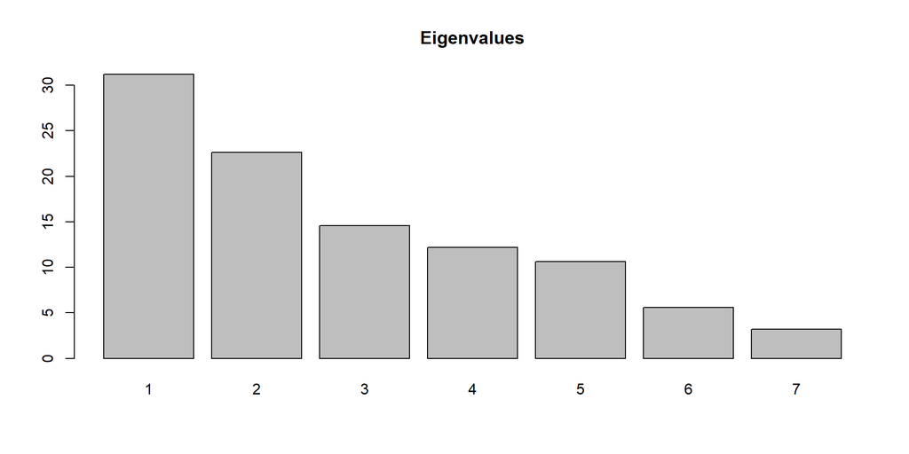

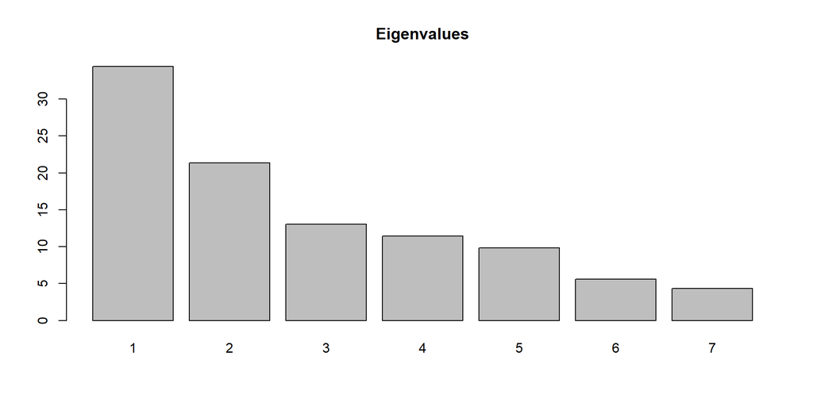

#### 2. Graphiques : nuage des individus et cercle de qualité des projections

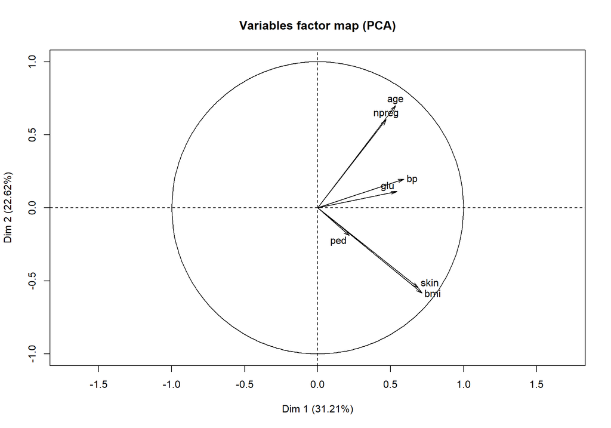

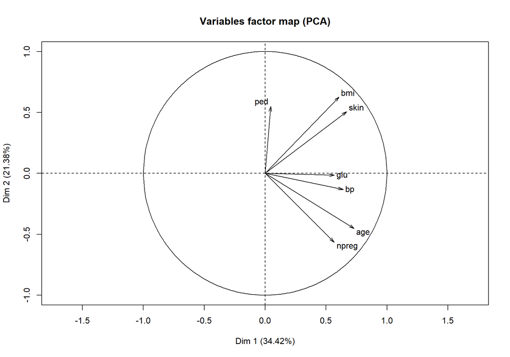

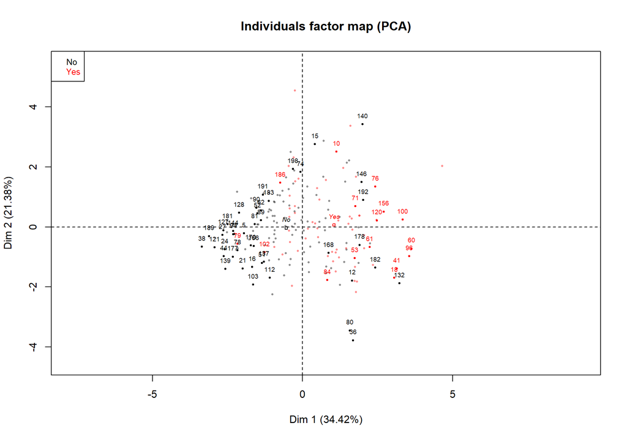

#### 3. coefficients de corrélation entre chacunes des variables et les 5 premières composantes principales

(ce qui correspond aux coordonnées des individus sur les 5 premiers axes) ##### A partir de la fonction dimdesc

```r
dimdesc <- dimdesc(res.pca, proba=1e-5) #, nbelements = 16)
dimdesc
```

```
## $Dim.1
## $Dim.1$quanti
##       correlation       p.value
## bmi     0.7151426 2.911247e-121
## skin    0.6886640 4.752896e-109
## bp      0.5916990  1.011090e-73
## glu     0.5441218  2.122215e-60
## age     0.5341338  7.249374e-58
## type    0.4824408  5.074879e-46
## npreg   0.4691698  2.709822e-43
## ped     0.2170849  1.210317e-09
##
##
## $Dim.2
## $Dim.2$quanti
##       correlation       p.value
## age     0.7001475 3.514964e-114
## npreg   0.6040157  1.524815e-77
## bp      0.1978220  3.239153e-08
## ped    -0.1897624  1.167582e-07
## skin   -0.5469590  3.903585e-61
## bmi    -0.5840856  1.931375e-71
##
##
## $Dim.3
## $Dim.3$quanti
##       correlation       p.value
## ped     0.8439140 2.345694e-209
## glu     0.4058998  8.002481e-32
## type    0.1685311  2.646606e-06
## npreg  -0.2166516  1.307765e-09
## skin   -0.2629382  1.305768e-13
```

##### Graphique de corrélation avec corrplot

```
##       Dim.1 Dim.2 Dim.3 Dim.4 Dim.5
## npreg  0.47  0.60 -0.22  0.48 -0.07
## glu    0.54  0.11  0.41 -0.37 -0.62
## bp     0.59  0.20 -0.04 -0.55  0.52
## skin   0.69 -0.55 -0.26  0.22 -0.06
## bmi    0.72 -0.58 -0.16  0.03  0.01
## ped    0.22 -0.19  0.84  0.35  0.29
## age    0.53  0.70  0.03  0.09  0.06
```

```
##       Dim.1 Dim.2 Dim.3 Dim.4 Dim.5
## npreg  0.57 -0.57  0.08  0.45 -0.11
## glu    0.57 -0.02  0.40 -0.61 -0.37
## bp     0.64 -0.13 -0.09 -0.30  0.68
## skin   0.67  0.51 -0.32  0.12 -0.13
## bmi    0.61  0.63 -0.23  0.10 -0.09
## ped    0.05  0.55  0.75  0.29  0.22
## age    0.73 -0.45  0.14  0.18 -0.05
```

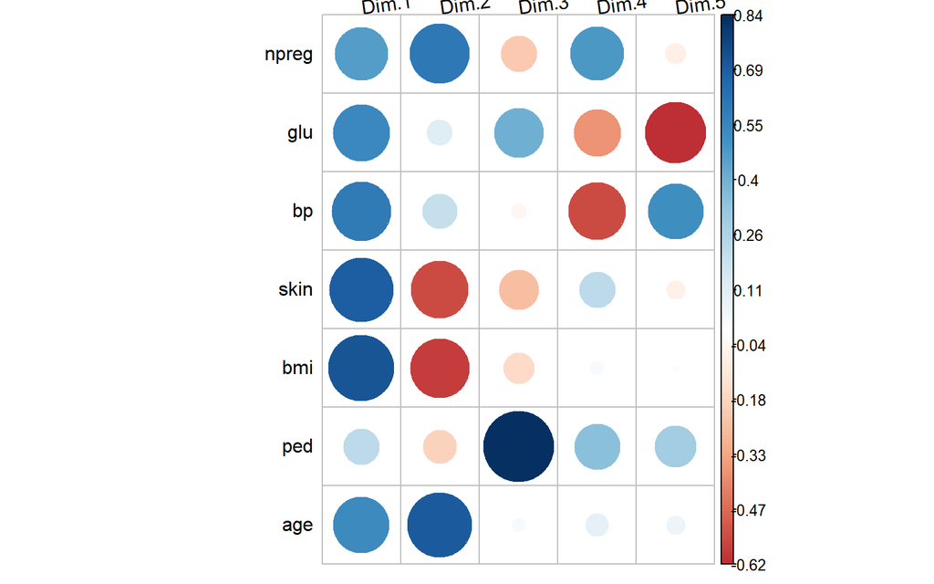

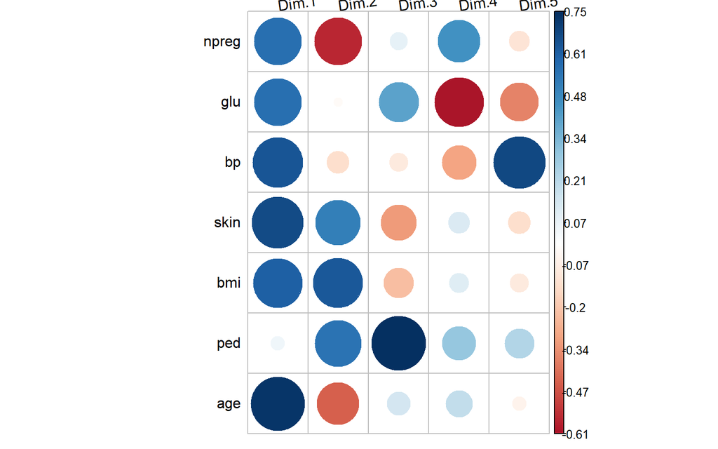

#### 4. Indice de qualité de la représentation cos2

```
##       Dim.1 Dim.2 Dim.3 Dim.4 Dim.5
## npreg  0.22  0.36  0.05  0.23  0.00
## glu    0.30  0.01  0.16  0.14  0.38
## bp     0.35  0.04  0.00  0.30  0.27
## skin   0.47  0.30  0.07  0.05  0.00
## bmi    0.51  0.34  0.02  0.00  0.00
## ped    0.05  0.04  0.71  0.12  0.08
## age    0.29  0.49  0.00  0.01  0.00
```

```
##       Dim.1 Dim.2 Dim.3 Dim.4 Dim.5
## npreg  0.32  0.32  0.01  0.20  0.01
## glu    0.32  0.00  0.16  0.37  0.14
## bp     0.41  0.02  0.01  0.09  0.47
## skin   0.45  0.26  0.10  0.01  0.02
## bmi    0.37  0.39  0.05  0.01  0.01
## ped    0.00  0.30  0.56  0.08  0.05
## age    0.54  0.20  0.02  0.03  0.00
```

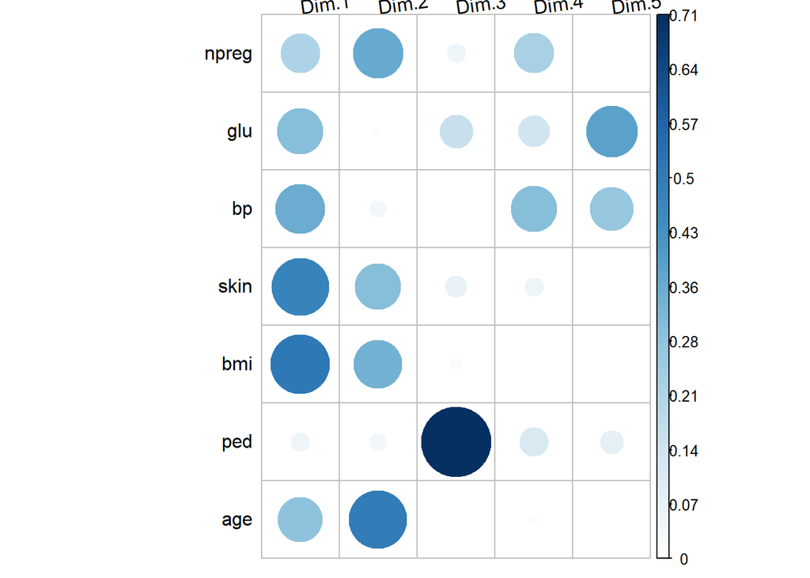

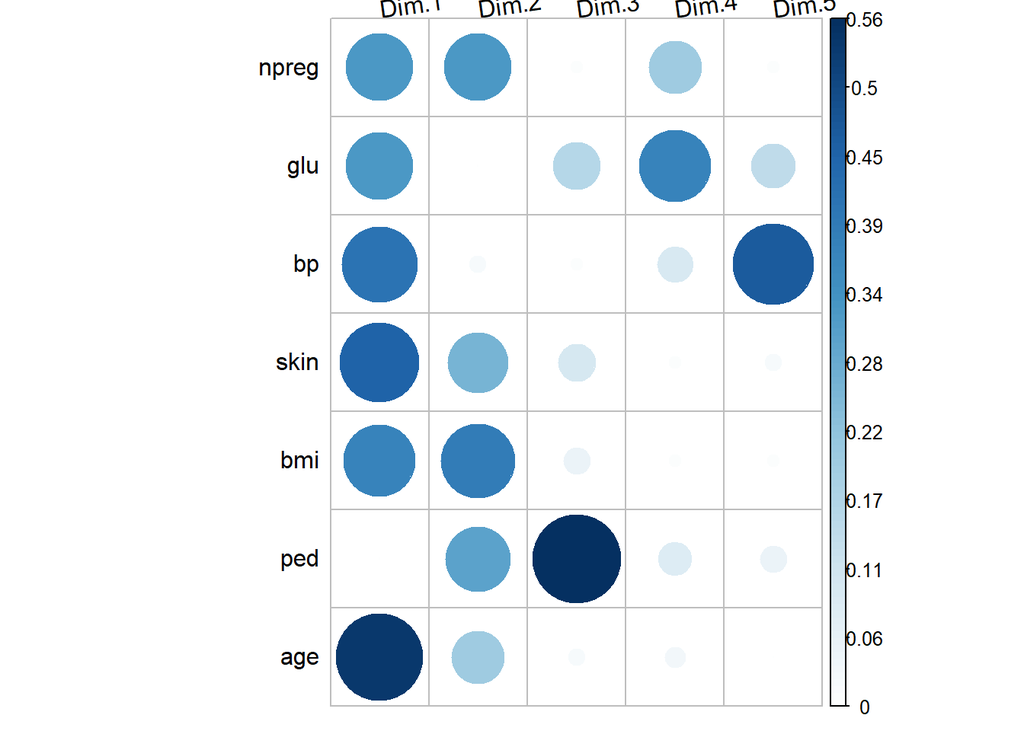

#### 5. Contribution des variables à la construction des axes

```
##       Dim.1 Dim.2 Dim.3 Dim.4 Dim.5
## npreg 10.08 23.05  4.60 27.37  0.63
## glu   13.55  0.80 16.16 15.91 51.26
## bp    16.03  2.47  0.16 35.74 36.16
## skin  21.71 18.90  6.78  5.74  0.47
## bmi   23.41 21.55  2.39  0.13  0.03
## ped    2.16  2.27 69.85 14.12 11.05
## age   13.06 30.96  0.07  1.00  0.41
```

```
##       Dim.1 Dim.2 Dim.3 Dim.4 Dim.5
## npreg 13.36 21.39  0.73 25.06  1.75
## glu   13.40  0.02 17.49 46.25 19.79
## bp    17.02  1.17  0.81 11.22 67.89
## skin  18.62 17.19 11.35  1.77  2.38
## bmi   15.30 26.30  5.81  1.30  1.08
## ped    0.08 20.24 61.63 10.53  6.73
## age   22.21 13.69  2.18  3.87  0.38
```

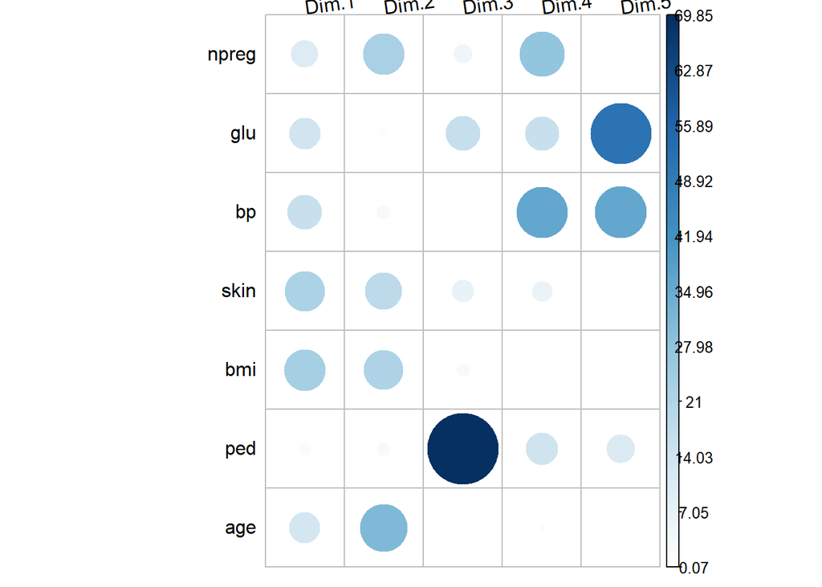

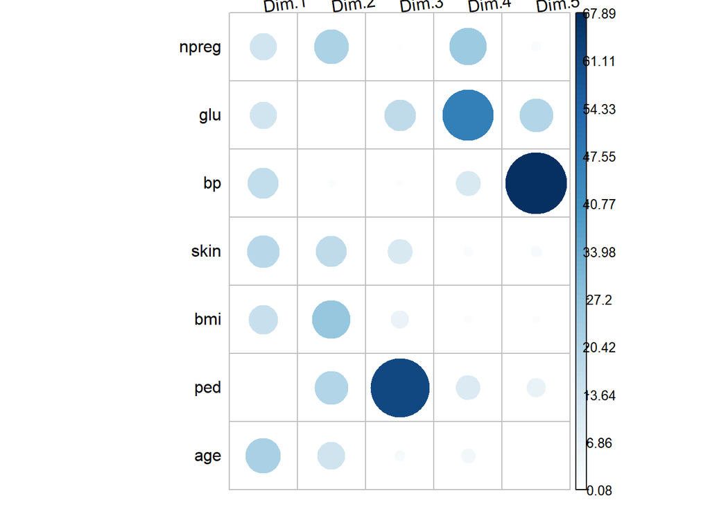

Intérêt : Les données Pima sont très utilsées (cf. Kaggle) pour autant il ne semble pas qu’un modèle d’inputation ait été utilisé. Bien souvent les données manquantes sont supprimés ou bien imputatikon simple par moyenne.